# High level statistics of the dataset:

# Lets do on the basis of Age

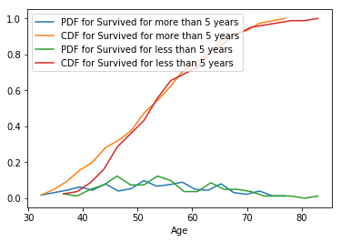

```python
import pandas as pd
import numpy as np
import matplotlib.pyplot as plt
import seaborn as sns

hbdata = pd.read_csv(r"D:\AppliedAI\Homework n Assignments\habermans-survival-data-set\haberman.csv")
hbdata.columns = ["Age","Year_of_Operation","Positive_Nodes","Survived_after_5_Years"]
hbdata["Survived_after_5_Years"]=hbdata["Survived_after_5_Years"].map({1:"yes",2:"no"})
survived_longer = hbdata.loc[hbdata["Survived_after_5_Years"]=="yes"]
survived_lesser = hbdata.loc[hbdata["Survived_after_5_Years"]=="no"]
counts, bin_edges = np.histogram(survived_longer['Age'], bins=20,
                                 density = True)
counts2, bin_edges2 = np.histogram(survived_lesser['Age'], bins=20,density = True)

pdf = counts/(sum(counts))
pdf2 = counts2/(sum(counts2))
cdf = np.cumsum(pdf)
cdf2 = np.cumsum(pdf2)
plt.plot(bin_edges[1:],pdf,label = "PDF for Survived for more than 5 years");
plt.plot(bin_edges[1:], cdf, label = "CDF for Survived for more than 5 years")
plt.plot(bin_edges2[1:],pdf2,label = "PDF for Survived for less than 5 years");
plt.plot(bin_edges2[1:], cdf2, label = "CDF for Survived for less than 5 years")
plt.xlabel("Age")
plt.legend()
plt.show()
```

# Conclusions

OK now we get some clearer picture regarding "age" variablle.

1. The Blue line is pretty much constant through out means probability of people living more or less than 5 years in pretty much same irrespective of age. Thus we should NOT BE making any conclusions on the basis of age.
2. The same trend can be seen with respect to green line it is pretty much constant and straight and thus we should not be concluding on the basis of age.
3. There is natural bend downwards for both green and blue line as age increases with is pretty natural as people become old there tendeny to live more than 5 years is reducing and thus a donward bend trend can be observed

#### So moving forward i wont be doing much analysis for age much. We are left with Box and Violin plot. Lets dig in that

# Lets do Box Plot

## Box Plot on the basis of Positive Nodes

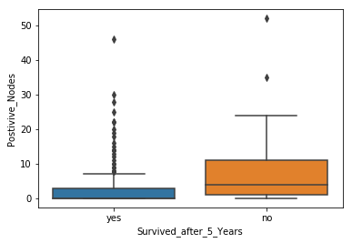

```python
import pandas as pd
import numpy as np
import matplotlib.pyplot as plt
import seaborn as sns

hbdata = pd.read_csv(r"D:\AppliedAI\Homework n Assignments\habermans-survival-data-set\haberman.csv")
hbdata.columns = ["Age","Year_of_Operation","Positive_nodes","Survived_after_5_Years"]
hbdata["Survived_after_5_Years"]=hbdata["Survived_after_5_Years"].map({1:"yes",2:"no"})
sns.boxplot(x='Survived_after_5_Years',y='Positive_nodes', data=hbdata)
plt.show()
```

# Conclusions

1. So we can see the blue box which gives us clear picture of quantile tells us almost 75% of people who lived more than 5 years has positive nodes less than 4 or so .
2. Almost 75% of people who did not lived longer than five years had positive nodes less than 12 or so

## Box Plot on the basis of Age

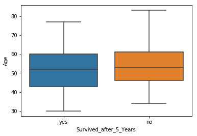

```python
import pandas as pd
import numpy as np
import matplotlib.pyplot as plt
import seaborn as sns

hbdata = pd.read_csv(r"D:\AppliedAI\Homework n Assignments\habermans-survival-data-set\haberman.csv")
hbdata.columns = ["Age","Year_of_Operation","Positive_nodes","Survived_after_5_Years"]
hbdata["Survived_after_5_Years"]=hbdata["Survived_after_5_Years"].map({1:"yes",2:"no"})
sns.boxplot(x='Survived_after_5_Years',y='Age', data=hbdata)
plt.show()
```

# Conclusion

Age is not such a good "variable" to conclude much

# Lets do Violin Plot

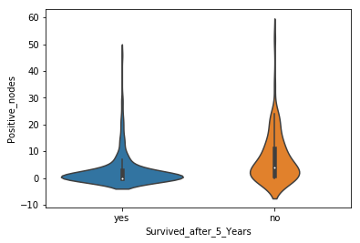

```python
import pandas as pd
import numpy as np
import matplotlib.pyplot as plt
import seaborn as sns

hbdata = pd.read_csv(r"D:\AppliedAI\Homework n Assignments\habermans-survival-data-set\haberman.csv")
hbdata.columns = ["Age","Year_of_Operation","Positive_nodes","Survived_after_5_Years"]
hbdata["Survived_after_5_Years"]=hbdata["Survived_after_5_Years"].map({1:"yes",2:"no"})
sns.violinplot(x="Survived_after_5_Years", y="Positive_nodes", data=hbdata, size=8)
plt.show()
```

# Conclusion

1. From this we can conclude that it might be true that for both people staying more than five years and people less than five years had lesser number of Positive Nodes but the blue violin (i.e.) that of people staying more than five years is more fatter when positive nodes is near zero.
2. Thus we can conclude people with positive nodes near zero has "more" probability of staying more than 5 years compared to having positive nodes more than zero. Further the violin for people living less than 5 years keep still has some width when positive nodes is large but the blue violin width almost vanishes when postive nodes increases thus further solidyfying our conclusion